# ANALYZING LONDON FIRE BRIGADE'S TOTAL RESPONSE TIME FOR FIRE INCIDENCES

```python
%%HTML
<script src="require.js"></script>
```

## PACKAGES USED

The project makes use of the standard packages in python such as pandas, numpy, matplotlob, etc as well as additional packages such as pyproj [1], haversine [2], graphviz [3], pillow [4], IPython display [5]

```python
import pandas as pd
import numpy as np
import sqlite3
import seaborn as sns
import seaborn.objects as so
import matplotlib.pyplot as plt
import warnings
import pyproj
import scipy.stats as stats
from sqlalchemy import create_engine, text
from sklearn.metrics.pairwise import haversine_distances
from math import radians
from graphviz import Graph
from PIL import Image
from IPython.display import display
```

## FUNCTIONS USED

This portion of the document is dedicated for defining global helper functions for the project.

### GET DISTANCE BETWEEN TWO COORDINATES IN LONGITUDE AND LATITUDE FORMAT

The function geocode_to_km(fs_lat, fs_long, inc_lat, inc_long) calculates the geographical distance in kilometers between a fire station and an incident location. Both locations are specified by their latitude and longitude coordinates. The function uses the Haversine formula to calculate the great-circle distance between two points on the Earth’s surface, which gives the shortest distance over the Earth’s surface, giving a best approximation of the distance between the points mentioned. The calculated distance is then returned as a float rounded to two decimal places. This function is useful in scenarios where you need to determine the geographical distance between two points when their coordinates are known.

```python
def geocode_to_km(fs_lat, fs_long, inc_lat, inc_long):
    """
    Get distance in kilometers between
    two geographical points that are
    in latitude and longitude format

    Parameters
    -------
    fs_lat : float
        Latitude of firestation

    fs_long : float
        Longitude of firestation

    inc_lat : float
        Latitude of incident area

    inc_long : float
        Longitude of incident area

    Returns
    -------
    Integer
        Distance in kilometers
    """
    earth_radius = 6371  # AVERAGE EARTH RADIUS AT LONDON
    # GEO CODES
    firestation = [fs_lat, fs_long]
    incident = [inc_lat, inc_long]

    # RADIANS CONVERSION
    fs_radians = [radians(geocode) for geocode in firestation]
    inc_radians = [radians(geocode) for geocode in incident]

    # COMPUTE FOR DISTANCE
    distance = haversine_distances([fs_radians, inc_radians])
    distance = distance * earth_radius
    return round(distance[0, 1], 2)
```

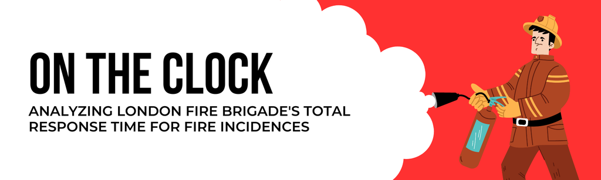

# I. ABSTRACT

In addition to temporal features, this study also incorporated geospatial analysis as it was important to factor the distance from the station to the incidences when considering Total Response Time. This information was not directly accessible but could be obtained through feature engineering.

This study concludes in identifying the seasonality, time-of-day, distance, occurrence of delays, and address type as key factors influencing total response time.

# II. PROJECT OBJECTIVES AND GOALS

The objective of this project, titled "Investigating Fire Incident Response Effectiveness in London: January 2020 - August 2023," is to analyze data from the "London Fire Brigade Incident Records" and "London Fire Brigade Mobilization Records", and to identify and understand the various factors that influence the effectiveness of the London Fire Department's response to fire incidents. This analysis aims to explore the relationships between geographic, temporal, other incident and response descriptors to assess how these factors affect response times. We will use exploratory data analysis (EDA) to gain insights on the different types of fire incidences and typical characteristics of the responses and provide recommendations.

## A. PROBLEM STATEMENT

There have been several high profile fire incidents in London from 2022 to 2023, including the Wennington wildfire which encountered mobilisation response issues from the London Fire Brigade. [6] The London Fire Brigade (LFB) needs to improve the performance of fire stations in order to reduce response times and improve incident resolution times.

**What are the key factors that contribute to the London Fire Brigade's incident response times?**

## B. MOTIVATION

Fires can be devastating, causing loss of life, property damage, and environmental destruction. In London, the London Fire Brigade (LFB) responds to thousands of fire incidents each year. To protect the public and minimize the impact of fires, the LFB needs to understand when and where they happen.

The LFB has incident records and mobilization records datasets that contain valuable data that can be used to identify patterns in fire incident and mobilization data. For example, this data can show the times of day when fire incidents are most common, the property types in London where fire incidents are most common, and the mobilization response time of each fire station.

By using fire incident and mobilization data, the LFB can improve its efficiency, effectiveness, and accountability. This can lead to better outcomes for the public, such as a reduction in the number of fire incidents and the impact of fires.

# III. METHODOLOGY

## A. Methodology Overview

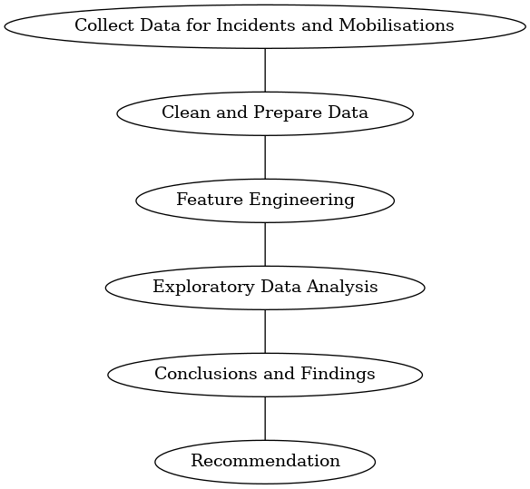

```python
# Instantiate a new Graph object
dot = Graph('Methodology Overview', format='png')

# Add nodes
dot.node('A', 'Collect Data for Incidents and Mobilisations')
dot.node('B', 'Clean and Prepare Data')
dot.node('C', 'Feature Engineering')
dot.node('D', 'Exploratory Data Analysis')
dot.node('E', 'Conclusions and Findings')
dot.node('F', 'Recommendation')

# Connect these nodes
dot.edges(['AB', 'BC', 'CD', 'DE', 'EF'])

# Save chart
dot.render('methodology_flowchart', view=False)

img = Image.open('methodology_flowchart.png')
display(img)
```

The primary goal of this report is to explore the multitude of factors that impact the response time of the London Fire Brigade when responding to incidents. To accomplish this aim, a series of data science procedures are imperative. The initial stage entails data collection, during which incident and mobilization data for the London Fire Brigade will be acquired from Jojie. The subsequent phase revolves around data cleaning and preparation, encompassing tasks such as establishing an SQL database, merging datasets, filtering datasets, reclassifying features, and eliminating columns and rows containing missing values. Moving on to the third phase, we engage in feature engineering, where the team introduces novel columns based on the original features, and these newly crafted columns will play a pivotal role in advancing to the subsequent phase of the analysis. The fourth step involves exploratory data analysis, where the team primarily employs data visualization and statistical techniques to uncover key insights. The fifth step comprises the conclusion section, where all the findings from the exploratory data analysis are synthesized and discussed. Finally, in the recommendation phase, the team delves into potential research directions that other researchers can pursue, considering the constraints and limitations of our data. This section highlights areas of study beyond our scope that hold promise for further investigation.

## B. Methodology Discussion

### B.1 Data Collection / Data Cleaning and Preparation

The first two steps of the methodology - data collection, and data cleaning and preparation - are connected in the flow of the report.

**Data collection deals with how data is being sourced:**

The team drew two datasets from Jojie's public repository; these are the London Fire Brigade datasets on incidents and mobilisations from January 2020 to August 2023.

To get a better understanding of the dataset about the dataset, the research team consulted the London Fire Brigade (LFB) database to extract metadata information.

**Data preparation refers to transforming the data in order to conduct data analysis:**

Initially, the researchers gathered geocodes for all 102 fire stations under the London Fire Brigade (LFB) and stored this information in a structured data frame, which was subsequently saved in an SQL database.

Data filtering was then implemented to focus exclusively on fire incidents and initial mobilizations while excluding secondary fires from the dataset.

In the process, an SQL database was established to accommodate all pertinent tables, including those for incidents and mobilizations, an unclean version of the merged incidents and mobilizations (unclean_lfb_table), a table uniting the lfb_table with fire station geocodes, and a table dedicated to the refined version of the LFB data, where data was meticulously filtered, reclassified, and null values were eliminated.

Notably, for null value treatment, both columns and rows that were deemed irrelevant to the data exploration were removed. Additionally, Delay Codes were reclassified as 0 or 1 to facilitate the identification of delays in mobilizations.

The resulting dataset we worked with contained 31,462 rows with 55 columns.

### B.2 Feature Engineering

The research team introduced five new significant columns to our dataset, namely, IncidentLongitude, IncidentLatitude, DistanceToIncident (KM), TravelSpeed (KM/HR), and TotalResponseTime.

The creation of the IncidentLongitude and IncidentLatitude columns played a pivotal role in calculating the distance between fire incidents and fire stations. Subsequently, we harnessed the longitude and latitude data to derive the DistanceToIncident (KM) column, which encapsulates the exact distance between the incident location and the nearest fire station. To comprehensively analyze the efficiency of fire pumps in relation to the distance of fire incidents, the TravelSpeed (KM/HR) column was introduced.

Additionally, a novel column, Total Response Time, was incorporated to serve as a metric for assessing the performance of each fire station in terms of their response time to fire incidents.

### B.3 Exploratory Data Analysis

The research team employed both visualization methods and statistical analysis to conduct exploratory data analysis. This analysis unfolded in two distinct phases. The initial phase involved an examination of the response time in its entirety, while the subsequent phase focused on dissecting the components of response time, namely turnout time, travel time, and attendance time, for a more granular understanding.

For assessing overall response time and its components:

- Time-series and histogram plots are used to visualize trends and distributions
- Bar graphs are used to rank the performance of categories.
- Measures of central tendency as well as other statistical values (confidence intervals and inter quartile range) are used to describe data.
- Scatterplots are used to analyze the relationship between features (Ex. speed of fire trucks and the distance to incident for each fire station)
- Tables are used to allow comparison of values

### B.4 Conclusion and Recommendation

In the conclusion section, the research team looked at the various factors that affect how quickly fire stations respond to incidents. Discussion for this section are broken down into four main topics, which are findings on: overall response time, turnout time, travel time, and attendance time.

For the recommendations, the reasearch team addressed the diverse limitations associated with our study, primarily pertaining to the datasets and parameters utilized, as well as the methods of conversion and time constraints. These limitations prompted our consideration of potential avenues for future research in this field, including the exploration of cross-feature analyses centered on response time data.

# IV. DATA COLLECTION

The Data Collection section describes how we sourced our data and what the data contains.

## A. Data Sources

The project will make use of two (2) of secondary data from the JOJIE public dataset (directory: /mnt/data/public/lfb/): London Fire Brigade Incident Records **(Incidents Dataset)**, and London Fire Brigade Mobilization Records **(Mobilisation Dataset)** which will be connected using the IncidentNumber Column in order to further investigate, and analyze how the LFB responded to each incident. For the data collection section, the project will undergo data cleansing for null, not a number (NaN), and double-entry cells, and identify its corresponding relevance to the project.

The team chose the following dataset found in the following directories:

1. **Incidents Dataset** (directory: `/mnt/data/public/lfb/LFB Incident data from January 2020 to August 2023.xlsx`)
2. **Mobilisation Dataset** (directory: `/mnt/data/public/lfb/mobilisation/LFB Mobilisation/data Last 3 years January 2020 to August 2023.xlsx`)

Both Datasets are in Excel File (.xlsx) file format and were used to create an SQL database. Many of these columns describe various characteristics of the incident and LFB’s mobilisation response. The team decided to apply minimal data preprocessing to preserve only the relevant information found on the datasets.

### A.1 London Fire Brigade Incident Records

The team preprocessed the Incidents Dataset by filtering out all that is not fire incidents in the dataset. Incident Records contain the details of every fire incident the LFB attended from January 2020 to August 2023.

The Incidents Dataset contains 414,249 entries (rows) and 39 base feature (columns).

### A.2 London Fire Brigade Mobilization Records

The team decided not to perform any data preprocessing for Mobilisation Dataset to keep the dataset intact and preserve all of the information found in the dataset. The Mobilisation Records contain data about the incidents attended by the London Fire Brigade Fire Pumps(engines) including the fire station area where the incident happened; Information is provided for the pump mobilised, where it was deployed from and the times recorded for arriving at the incident.

The Mobilisation Dataset contains 608,514 entries (rows) and 22 base features (columns)

## B. Data Description

### B.1 Row Description

Each of the row entry from London Fire Brigade Incident Records Dataset represent an incident which the London Fire Brigade got called to act, and each of the row entry from London Fire Brigade Mobilization Records Dataset corresponds to varying number of mobilization depending on the type of incident.

### B.2 Column Description and Metadata

We gathered the metadata information from the UK Government's Website for the London Fire Brigade [7] [8]

#### B.2.1 Incidents Dataset Metadata

| Feature Name | Sample Record | Feature Description | Extra Notes | Data Type |
| --- | --- | --- | --- | --- |
| IncidentNumber | 000008-01012018 | LFB Incident Number |  | object |
| DateOfCall | 01/01/2018 | Date of 999 call |  | datetime64[ns] |
| CalYear | 2018 | Year of 999 call |  | int64 |
| TimeOfCall | 12:04:25 am | Time of 999 call |  | object |
| HourOfCall | 0 | Time of 999 call |  | int64 |
| IncidentGroup | False Alarm | High level incident category |  | object |
| StopCodeDescription | AFA | LFB Incident Number |  | object |
| SpecialServiceType |  | Further detail for special services incident categories |  | object |
| PropertyCategory | Non Residential | High level property descriptor |  | object |
| PropertyType | Mosque | Detailed property descriptor |  | object |
| AddressQualifier | Within same building | Qualifies location of actual incident relevant to category above |  | object |
| Postcode_full | N2 8AY | Postcode | redacted for Dwellings | object |
| Postcode_district | N2 | Postcode Districs |  | object |
| UPRN | 200220110 | Unique Property Reference Number | redacted for Dwellings | int64 |
| USRN | 20013420 | Unique Street Reference Number |  | int64 |
| IncGeo_BoroughCode | E09000003 | Borough Code |  | object |
| IncGeo_BoroughName | BARNET | Borough Name |  | object |
| ProperCase | Barnet | Borough Name |  | object |
| IncGeo_WardCode | E05000049 | Ward Code |  | object |
| IncGeo_WardName | EAST FINCHLEY | Ward Name |  | object |
| IncGeo_WardNameNew | EAST FINCHLEY | New Ward Name |  | object |
| Easting_m | 527184 | Easting | redacted for Dwellings | float64 |
| Northing_m | 189488 | Northing | redacted for Dwellings | float64 |
| Easting_rounded | 527150 | Easting rounded up to nearest 50 |  | int64 |
| Northing_rounded | 189450 | Northing rounded up to nearest 50 |  | int64 |
| Latitude | 51.58990022 | Latitude | redacted for Dwellings | float64 |
| Longitude | -0.165452578 | Longitude | redacted for Dwellings | float64 |
| FRS | London | Fire Service ground |  | object |
| IncidentStationGround | Finchley | LFB Station ground |  | object |
| FirstPumpArriving_AttendanceTime | 348 | First Pump attendance time in seconds |  | float64 |
| FirstPumpArriving_DeployedFromStation | Finchley | First Pump deployed from station |  | object |
| SecondPumpArriving_AttendanceTime |  | Second Pump attendance time in seconds |  | float64 |
| SecondPumpArriving_DeployedFromStation |  | Second Pump deployed from station |  | object |
| NumStationsWithPumpsAttending | 1 | Number of stations with pumps in attendance |  | float64 |
| NumPumpsAttending | 1 | Number of pumps in attendance |  | float64 |
| PumpCount | 1 |  |  | float64 |
| PumpHoursRoundUp | 1 | Time spent at incident by pumps, rounded up to nearest hour |  | float64 |
| Notional Cost (£) | 328 | Time spent multiplied by notional annual cost of a pump |  | float64 |
| NumCalls | 2 | Number of Calls concerning the incident |  | int64 |

#### B.2.2 Mobilisation Dataset Metadata

| Feature Name | Sample Record | Feature Description | Data Type |
| --- | --- | --- | --- |
| IncidentNumber | 000008-01012018 | LFB Incident Number | object |
| CalYear | 2018 | Year of 999 call | int64 |
| HourOfCall | 3 | Hour of 999 call | int64 |
| ResourceMobilisationId | 5055153 | LFB Resource Mobilisation ID | int64 |
| Resource_Code | A392 | LFB Resource Code | object |
| PerformanceReporting | 1 | First Pump arrived at incident | object |
| DateAndTimeMobilised | 01/01/2018 00:04:25 | Date and time of mobilised (GMT) | object |
| DateAndTimeMobile | 01/01/2018 00:05:38 | Date and time of mobile (GMT) | object |
| DateAndTimeArrived | 01/01/2018 00:10:13 | Date and time arrived (GMT) | object |
| TurnoutTimeSeconds | 73 | Turnout time in seconds | float64 |
| TravelTimeSeconds | 275 | Travel time in seconds | float64 |
| AttendanceTimeSeconds | 348 | Attendance time in seconds | int64 |
| DateAndTimeLeft | 01/01/2018 00:16:38 | Date and time of mobilised (GMT) | object |
| DateAndTimeReturned | 01/01/2018 12:22:45 am | Date and time returned to station (GMT) | float64 |
| DeployedFromStation_Code | A39 | Deployed from station code | object |
| DeployedFromStation_Name | Finchley | Deployed from station name | object |
| DeployedFromLocation | Home Station | Deployed from location | object |
| PumpOrder | 1 | Pump order | int64 |
| PlusCode_Code | Initial | Code of Plus Code | object |
| PlusCode_Description | Initial Mobilisation | Description of Plus Code | object |
| DelayCodeId | 9 | Delay code IDDelay code ID | float64 |
| DelayCode_Description | Traffic, roadworks, etc | Delay code description | object |

### B.3 Total Reponse Time

#### B.3.1 Turnout Time

The Turnout Time measures the time elapsed from when the emergency dispatcher informs the fire unit of an emergency and when the unit leaves the fire station. This is represented by the feature, TurnoutTimeSeconds, and is recorded in seconds.

#### B.3.2 Travel Time

The Travel Time is the time it takes for the fire unit to travel from the fire station to the incident location. Factors such as distance, traffic, and route can impact travel time. This is represented by the feature, TravelTimeSeconds, and is recorded in seconds.

#### B.3.3 Attendance Time

The Attendance Time refers to the arrival of the first fire truck or fire engine at the scene of a fire or other emergency. This is crucial as it marks when firefighting and rescue services begin. Is is measured as the time it takes for the initial responding unit to arrive and start providing firefighting and rescue services. This is represented by the feature, AttendanceTimeSeconds, and is recorded in seconds.

## C. Data Preparation

### C.1 Load Data from XLSX

```python
path_incidents = ("/mnt/data/public/lfb/LFB Incident data "
                  "from January 2020 to August 2023.xlsx")
df_incidents = pd.read_excel(path_incidents)
```

```python
path_mobilisation = ("/mnt/data/public/lfb/mobilisation/LFB Mobilisation "
                     "data Last 3 years January 2020 to August 2023.xlsx")
df_mobilisation = pd.read_excel(path_mobilisation)
```

### C.2 Create SQL Tables (Incident and Mobilisation Tables)=

```python
with sqlite3.connect('lfb_db.db') as conn:
    df_incidents.to_sql('incidents_table', conn,
                        if_exists='replace', index=False)
    df_mobilisation.to_sql('mobilisation_table', conn,
                           if_exists='replace', index=False)
```

### C.3 Create Firestation Geocodes Table

Contains the Longitude and Latitude Data of each Station under the London Fire Brigade

```python
# FIRESTATIONS GEOCODE DATA
fs_geocodes = {
    'DeployedFromStation_Name': [
        'Acton', 'Addington', 'Barking', 'Barnet', 'Battersea',
        'Beckenham', 'Bethnal Green', 'Bexley','Biggin Hill',
        'Brixton', 'Bromley', 'Chelsea', 'Chingford', 'Chiswick',
        'Clapham', 'Croydon', 'Dagenham', 'Deptford', 'Dockhead',
        'Dowgate', 'Ealing', 'East Greenwich', 'East Ham', 'Edmonton',
        'Eltham', 'Enfield', 'Erith', 'Euston', 'Feltham', 'Finchley',
        'Forest Hill', 'Fulham', 'Greenwich', 'Hainault', 'Hammersmith',
        'Harold Hill', 'Harrow', 'Hayes', 'Heathrow', 'Hendon', 'Heston',
        'Hillingdon','Holloway', 'Homerton', 'Hornchurch', 'Hornsey',
        'Ilford', 'Islington', 'Kensington', 'Kentish Town', 'Kingston',
        'Lambeth', 'Lee Green', 'Lewisham', 'Leyton', 'Leytonstone',
        'Mill Hill', 'Millwall', 'Mitcham', 'New Cross', 'New Malden',
        'Norbury', 'North Kensington', 'Northolt', 'Old Kent Road',
        'Orpington', 'Paddington', 'Park Royal', 'Peckham', 'Plaistow',
        'Plumstead', 'Poplar', 'Purley','Richmond', 'Romford', 'Ruislip',
        'Shadwell', 'Shoreditch', 'Sidcup', 'Soho', 'Southall', 'Southgate',
        'Stanmore', 'Stoke Newington', 'Stratford', 'Surbiton', 'Sutton',
        'Tooting', 'Tottenham', 'Twickenham', 'Wallington', 'Walthamstow',
        'Wandsworth', 'Wembley', 'Wennington', 'West Hampstead',
        'West Norwood','Whitechapel', 'Willesden', 'Wimbledon',
        'Woodford', 'Woodside'
    ],
    'StationLatitude': [
        51.50725194, 51.35195765, 51.52984058, 51.64716464, 51.4672469,
        51.40825911, 51.53554288, 51.46120972, 51.31378276, 51.4639531,
        51.40826838, 51.48736274, 51.62956486, 51.49074498, 51.46501642,
        51.37004841, 51.55929984, 51.48505047, 51.50077223, 51.51016975,
        51.51209449, 51.48710443, 51.52347376, 51.62730263, 51.45198946,
        51.66015756, 51.48553438, 51.52768496, 51.46062582, 51.59787635,
        51.44263609, 51.47813259, 51.4744153, 51.60639442, 51.49646599,
        51.59841136, 51.59093414, 51.49453389, 51.48027667, 51.58902972,
        51.47503897, 51.53268226, 51.56164235, 51.548534, 51.56468624,
        51.58663366, 51.56240108, 51.5404114, 51.50290879, 51.55286464,
        51.42940427, 51.49263674, 51.45653257, 51.45708635, 51.5633209,
        51.56078973, 51.6150784, 51.5006246, 51.39732811, 51.47405227,
        51.39936189, 51.40693936, 51.52220875, 51.55491086, 51.48700633,
        51.372326, 51.52037096, 51.53604563, 51.47408134, 51.52121389,
        51.48761134, 51.51098301, 51.3318546, 51.46765774, 51.5937785,
        51.58854609, 51.51088014, 51.5265429, 51.427166, 51.51272222,
        51.51151799, 51.63058139, 51.60359467, 51.56256861, 51.54359303,
        51.39249379, 51.36923277, 51.43804963, 51.59265146, 51.43544049,
        51.36258641, 51.58978527, 51.45674003, 51.55180895, 51.50644185,
        51.55172599, 51.42597997, 51.51545912, 51.54444292, 51.41583716,
        51.6095268, 51.38600685
    ],
    'StationLongitude': [
        -0.277015475, -0.023958337, 0.08892025, -0.185917071, -0.169223621,
        -0.034173663, -0.054878117, 0.153658794, 0.03414348, -0.109438634,
        0.01726385, -0.170306842, -0.004798393, -0.269257968, -0.140943393,
        -0.104898393, 0.157098404, -0.033780391, -0.070697623, -0.090377004,
        -0.313806727, 0.022273246, 0.057096929, -0.069170719, 0.058575518,
        -0.052102416, 0.15665253, -0.130735614, -0.413679589, -0.179087439,
        -0.044769422, -0.201036727, -0.012967251, 0.104409723, -0.224272019,
        0.223889652, -0.366371658, -0.431799813, -0.458604431, -0.228668947,
        -0.343078225, -0.451726622, -0.116103509, -0.043843401, 0.220578458,
        -0.126976808, 0.09012212, -0.10240733, -0.190088139, -0.141791318,
        -0.306608198, -0.121531058, 0.012722391, -0.013529222, -0.016592299,
        0.008552482, -0.243127193, -0.025477484, -0.172806852, -0.048443123,
        -0.245247121, -0.121237961, -0.211831308, -0.359445583, -0.073637558,
        0.110842591, -0.182843399, -0.264539181, -0.077959232, 0.032038004,
        0.091381196, -0.014448652, -0.124941434, -0.284853009, 0.181181893,
        -0.436540716, -0.055870409, -0.085509559, 0.094554047, -0.129981998,
        -0.37453946, -0.127538081, -0.297549525, -0.076914429, 0.011168558,
        -0.29796971, -0.21109647, -0.162806813, -0.071507683, -0.347526583,
        -0.14822923, -0.028772188, -0.2014407, -0.303994667, 0.220525185,
        -0.192769475, -0.105497623, -0.068975236, -0.236511712, -0.197488768,
        0.024019433, -0.062417264
    ]
}

# CREATE FIRESTATION GEOCODES DF
df_fs_geocodes = pd.DataFrame(fs_geocodes)

# CREATE SQL TABLE FOR FIRESTATION GEOCODES
with sqlite3.connect('lfb_db.db') as conn_fs_geocodes:
    df_fs_geocodes.to_sql('fs_geocodes_table', conn_fs_geocodes,
                          if_exists='replace', index=False)
```

### C.4 Merging Data

The team merged the SQL tables of the main datasets - Incidents table and Mobilisation table on the IncidentNumber Field (ID).

We left joined Incident Records (incident_table) into the Mobilisation Records (mobilisation_table) using the IncidentNumber key. We will only be looking at the First mobilisation of pumps through filtering data under PerformanceReports that equal to 1.

#### C.4.1 Merge Mobilisation and Incident Table

```python
with sqlite3.connect('lfb_db.db') as conn:
    conn.execute("""
    CREATE TABLE IF NOT EXISTS incident_merged_mobil_table AS
    SELECT
        IncidentNumber, CalYear, HourOfCall,
        ResourceMobilisationId, Resource_Code,
        PerformanceReporting, DateAndTimeMobilised,
        DateAndTimeMobile, DateAndTimeArrived,
        TurnoutTimeSeconds, TravelTimeSeconds,
        AttendanceTimeSeconds, DateAndTimeLeft,
        DateAndTimeReturned, DeployedFromStation_Code,
        DeployedFromStation_Name, DeployedFromLocation,
        PumpOrder, PlusCode_Code, PlusCode_Description,
        DelayCodeId, DelayCode_Description, DateOfCall,
        TimeOfCall, IncidentGroup, StopCodeDescription,
        SpecialServiceType, PropertyCategory, PropertyType,
        AddressQualifier, Postcode_full, Postcode_district,
        UPRN, USRN, IncGeo_BoroughCode, IncGeo_BoroughName,
        ProperCase, IncGeo_WardCode, IncGeo_WardName,
        IncGeo_WardNameNew, Easting_m,Northing_m, Easting_rounded,
        Northing_rounded, Latitude,Longitude, FRS, IncidentStationGround,
        FirstPumpArriving_AttendanceTime,
        FirstPumpArriving_DeployedFromStation,
        SecondPumpArriving_AttendanceTime,
        SecondPumpArriving_DeployedFromStation,
        NumStationsWithPumpsAttending, NumPumpsAttending,
        PumpCount, PumpHoursRoundUp, [Notional Cost (£)],
        NumCalls
    FROM
        (SELECT
            *
        FROM
            mobilisation_table AS m
        LEFT JOIN
            incidents_table AS i
        ON
            m.IncidentNumber = i.IncidentNumber)
    WHERE
        PerformanceReporting = 1
    """)
```

#### C.4.2 Merge Fire Stations Geocodes Table to Merged Mobilisation and Incident Table

We link the merged table with geocodes table using DeployedFromStation_Name field. The geocodes table is data that identifies the Longitude and Latitude data of each LFB Fire station.

```python
with sqlite3.connect('lfb_db.db') as conn:
    conn.execute("""
    CREATE TABLE unclean_lfb_table AS
    SELECT
        imm.*,
        StationLatitude,
        StationLongitude
    FROM
        incident_merged_mobil_table AS imm
    INNER JOIN
        fs_geocodes_table as gc
    ON
        imm.DeployedFromStation_Name =
        gc.DeployedFromStation_Name
    """)
```

#### C.4.3 Check SQL Tables Created

##### C.4.3.1 Pull Unclean London Fire Brigade (LFB) Table

```python
with sqlite3.connect('lfb_db.db') as conn:
    data = pd.read_sql_query("""
    SELECT
        *
    FROM
        unclean_lfb_table
    """, conn)
```

##### C.4.3.2 View Head of Pulled Table

```python
print("UNCLEAN LONDON FIRE BRIGADE (LFB) DATA")
display(data.head())
```

```
UNCLEAN LONDON FIRE BRIGADE (LFB) DATA
```

|  | IncidentNumber | CalYear | HourOfCall | ResourceMobilisationId | Resource_Code | PerformanceReporting | DateAndTimeMobilised | DateAndTimeMobile | DateAndTimeArrived | TurnoutTimeSeconds | ... | SecondPumpArriving_AttendanceTime | SecondPumpArriving_DeployedFromStation | NumStationsWithPumpsAttending | NumPumpsAttending | PumpCount | PumpHoursRoundUp | Notional Cost (£) | NumCalls | StationLatitude | StationLongitude |
| --- | --- | --- | --- | --- | --- | --- | --- | --- | --- | --- | --- | --- | --- | --- | --- | --- | --- | --- | --- | --- | --- |
| 0 | 000003-01012020 | 2020 | 0 | 5547476 | G232 | 1 | 01/01/2020 00:06:30 | 01/01/2020 00:07:48 | 01/01/2020 00:11:54 | 78.0 | ... | 292.0 | Hillingdon | 1.0 | 2.0 | 2.0 | 1.0 | 339.0 | 3.0 | 51.532682 | -0.451727 |
| 1 | 000008-01012020 | 2020 | 0 | 5547478 | H421 | 1 | 01/01/2020 00:11:05 | 01/01/2020 00:12:05 | 01/01/2020 00:14:20 | 60.0 | ... | NaN | None | 1.0 | 1.0 | 1.0 | 1.0 | 339.0 | 1.0 | 51.467658 | -0.284853 |
| 2 | 000009-01012020 | 2020 | 0 | 5547479 | A341 | 1 | 01/01/2020 00:11:16 | 01/01/2020 00:13:04 | 01/01/2020 00:18:22 | 108.0 | ... | NaN | None | 1.0 | 1.0 | 1.0 | 1.0 | 339.0 | 1.0 | 51.627303 | -0.069171 |
| 3 | 000011-01012020 | 2020 | 0 | 5547482 | H351 | 1 | 01/01/2020 00:12:02 | 01/01/2020 00:13:08 | 01/01/2020 00:16:11 | 66.0 | ... | 255.0 | Tooting | 1.0 | 2.0 | 2.0 | 2.0 | 678.0 | 2.0 | 51.438050 | -0.162807 |
| 4 | 000015-01012020 | 2020 | 0 | 5547483 | H382 | 1 | 01/01/2020 00:12:53 | 01/01/2020 00:14:51 | 01/01/2020 00:21:39 | 118.0 | ... | NaN | None | 1.0 | 1.0 | 1.0 | 1.0 | 339.0 | 1.0 | 51.369233 | -0.211096 |

5 rows × 60 columns

##### C.4.3.3 List of SQL Tables under lfb_db.db

```python
with sqlite3.connect('lfb_db.db') as conn:
    tables = conn.execute("""
    SELECT
        name
    FROM
        sqlite_master
    WHERE
        type='table';
    """).fetchall()
    print('THE TABLES UNDER '
          'lfb_db.db ARE:\n')
    for table in tables:
        print(table[0])
```

```
THE TABLES UNDER lfb_db.db ARE:

incidents_table
mobilisation_table
fs_geocodes_table
incident_merged_mobil_table
unclean_lfb_table
```

### C.5 Filter Data

#### C.5.1 Pull Data from Unclean LFB Table

Select only rows where Incident Types are Fire and all the stop code descriptions are Primary Fires. This means we get to see data where the mobilised pump is the first pump to respond to the fire incident which is one of our main focuses on our data exploration.

```python
# QUERY
query = f"""
    SELECT
        *
    FROM
        unclean_lfb_table
    WHERE
        IncidentGroup = 'Fire'
        AND StopCodeDescription != 'Secondary Fire'
"""

df_lfb = pd.read_sql(query, 'sqlite:///lfb_db.db')
```

#### C.5.2 View Filtered Unclean LFB Table

```python
print('FILTERED UNCLEAN LFB TABLE')
display(df_lfb.head())
```

```
FILTERED UNCLEAN LFB TABLE
```

|  | IncidentNumber | CalYear | HourOfCall | ResourceMobilisationId | Resource_Code | PerformanceReporting | DateAndTimeMobilised | DateAndTimeMobile | DateAndTimeArrived | TurnoutTimeSeconds | ... | SecondPumpArriving_AttendanceTime | SecondPumpArriving_DeployedFromStation | NumStationsWithPumpsAttending | NumPumpsAttending | PumpCount | PumpHoursRoundUp | Notional Cost (£) | NumCalls | StationLatitude | StationLongitude |
| --- | --- | --- | --- | --- | --- | --- | --- | --- | --- | --- | --- | --- | --- | --- | --- | --- | --- | --- | --- | --- | --- |
| 0 | 000003-01012020 | 2020 | 0 | 5547476 | G232 | 1 | 01/01/2020 00:06:30 | 01/01/2020 00:07:48 | 01/01/2020 00:11:54 | 78.0 | ... | 292.0 | Hillingdon | 1.0 | 2.0 | 2.0 | 1.0 | 339.0 | 3.0 | 51.532682 | -0.451727 |
| 1 | 000017-01012020 | 2020 | 0 | 5547485 | F291 | 1 | 01/01/2020 00:15:59 | 01/01/2020 00:17:27 | 01/01/2020 00:20:40 | 88.0 | ... | 508.0 | Leytonstone | 2.0 | 2.0 | 2.0 | 2.0 | 678.0 | 2.0 | 51.563321 | -0.016592 |
| 2 | 000023-01012020 | 2020 | 0 | 5547491 | G272 | 1 | 01/01/2020 00:18:26 | 01/01/2020 00:19:40 | 01/01/2020 00:23:15 | 74.0 | ... | 360.0 | Paddington | 2.0 | 2.0 | 2.0 | 1.0 | 339.0 | 1.0 | 51.522209 | -0.211831 |
| 3 | 000040-01012020 | 2020 | 0 | 5547514 | E431 | 1 | 01/01/2020 00:28:31 | 01/01/2020 00:30:00 | 01/01/2020 00:33:41 | 89.0 | ... | 415.0 | Bromley | 2.0 | 2.0 | 2.0 | 1.0 | 339.0 | 1.0 | 51.408259 | -0.034174 |
| 4 | 000041-01012020 | 2020 | 0 | 5547523 | G241 | 1 | 01/01/2020 00:32:36 | None | 01/01/2020 00:35:35 | NaN | ... | 183.0 | Southall | 3.0 | 4.0 | 4.0 | 5.0 | 1695.0 | 3.0 | 51.511518 | -0.374539 |

5 rows × 60 columns

### C.6 Null Value Treatments

#### C.6.1 Show Null per Column

The team first retrieved all the nulls in the unclean_lfb_table to get an understanding of how to clean the data.

```python
print('NULL VALUES:\n')
display(df_lfb.isnull().sum())
```

```
NULL VALUES:
```

[output not shown]

#### C.6.2 Drop Columns with Nulls

We will eliminate columns that are not relevant to our data exploration. Additionally, these datasets contain a significant number of missing values, which could interfere with our data analysis. Therefore, the choice to remove these columns is warranted.

```python
columns_to_drop = ['SpecialServiceType', 'Postcode_full', 'Easting_m',
                   'Northing_m', 'Latitude', 'Longitude',
                   'SecondPumpArriving_AttendanceTime',
                   'SecondPumpArriving_DeployedFromStation',
                   'DateAndTimeReturned', 'DelayCode_Description'
                  ]

for column in columns_to_drop:
    if column in df_lfb:
        df_lfb.drop(columns=columns_to_drop, inplace=True)
    else:
        print(f"Column '{column}' does not exist in the DataFrame.")
```

```
Column 'Postcode_full' does not exist in the DataFrame.
Column 'Easting_m' does not exist in the DataFrame.
Column 'Northing_m' does not exist in the DataFrame.
Column 'Latitude' does not exist in the DataFrame.
Column 'Longitude' does not exist in the DataFrame.
Column 'SecondPumpArriving_AttendanceTime' does not exist in the DataFrame.
Column 'SecondPumpArriving_DeployedFromStation' does not exist in the DataFrame.
Column 'DateAndTimeReturned' does not exist in the DataFrame.
Column 'DelayCode_Description' does not exist in the DataFrame.
```

##### C.6.2.1 Null Values after Dropped Columns

```python
print('NULL VALUES AFTER DROPPED COLUMNS:\n')
df_lfb.isnull().sum()
```

```
NULL VALUES AFTER DROPPED COLUMNS:
```

```
IncidentNumber                               0
CalYear                                      0
HourOfCall                                   0
ResourceMobilisationId                       0
Resource_Code                                0
PerformanceReporting                         0
DateAndTimeMobilised                         0
DateAndTimeMobile                          127
DateAndTimeArrived                           0
TurnoutTimeSeconds                         129
TravelTimeSeconds                          127
AttendanceTimeSeconds                        0
DateAndTimeLeft                             14
DeployedFromStation_Code                     0
DeployedFromStation_Name                     0
DeployedFromLocation                        32
PumpOrder                                    0
PlusCode_Code                                0
PlusCode_Description                         0
DelayCodeId                              23114
DateOfCall                                   0
TimeOfCall                                   0
IncidentGroup                                0
StopCodeDescription                          0
PropertyCategory                             0
PropertyType                                 0
AddressQualifier                             0
Postcode_district                            0
UPRN                                         0
USRN                                         0
IncGeo_BoroughCode                           0
IncGeo_BoroughName                           0
ProperCase                                   0
IncGeo_WardCode                             11
IncGeo_WardName                             11
IncGeo_WardNameNew                          11
Easting_rounded                              0
Northing_rounded                             0
FRS                                          0
IncidentStationGround                        0
FirstPumpArriving_AttendanceTime             0
FirstPumpArriving_DeployedFromStation        0
NumStationsWithPumpsAttending                0
NumPumpsAttending                            0
PumpCount                                    0
PumpHoursRoundUp                             4
Notional Cost (£)                            4
NumCalls                                     0
StationLatitude                              0
StationLongitude                             0
dtype: int64
```

#### C.6.3 Drop Rows with Nulls

After dropping the columns, there are still entries with null values. The team decided to drop the entries affected by these null values since it only represents less than 1% of the size of the dataset.

```python
df_lfb.dropna(subset=['TurnoutTimeSeconds', 'TravelTimeSeconds',
                      'DeployedFromLocation', 'AttendanceTimeSeconds',
                      'DeployedFromStation_Name',
                      'PropertyCategory', 'PropertyType',
                      'AddressQualifier', 'Easting_rounded',
                      'Northing_rounded'
                      ], axis=0, inplace=True)
```

##### C.6.3.1 Null Values after Dropped Rows

```python
print('NULL VALUES AFTER DROPPED ROWS:\n')
display(df_lfb.isnull().sum())
```

```
NULL VALUES AFTER DROPPED ROWS:
```

```
IncidentNumber                               0
CalYear                                      0
HourOfCall                                   0
ResourceMobilisationId                       0
Resource_Code                                0
PerformanceReporting                         0
DateAndTimeMobilised                         0
DateAndTimeMobile                            0
DateAndTimeArrived                           0
TurnoutTimeSeconds                           0
TravelTimeSeconds                            0
AttendanceTimeSeconds                        0
DateAndTimeLeft                             13
DeployedFromStation_Code                     0
DeployedFromStation_Name                     0
DeployedFromLocation                         0
PumpOrder                                    0
PlusCode_Code                                0
PlusCode_Description                         0
DelayCodeId                              22967
DateOfCall                                   0
TimeOfCall                                   0
IncidentGroup                                0
StopCodeDescription                          0
PropertyCategory                             0
PropertyType                                 0
AddressQualifier                             0
Postcode_district                            0
UPRN                                         0
USRN                                         0
IncGeo_BoroughCode                           0
IncGeo_BoroughName                           0
ProperCase                                   0
IncGeo_WardCode                             11
IncGeo_WardName                             11
IncGeo_WardNameNew                          11
Easting_rounded                              0
Northing_rounded                             0
FRS                                          0
IncidentStationGround                        0
FirstPumpArriving_AttendanceTime             0
FirstPumpArriving_DeployedFromStation        0
NumStationsWithPumpsAttending                0
NumPumpsAttending                            0
PumpCount                                    0
PumpHoursRoundUp                             4
Notional Cost (£)                            4
NumCalls                                     0
StationLatitude                              0
StationLongitude                             0
dtype: int64
```

#### C.6.4 Re-classify Delay Codes as 0 or 1

We identified blank entries in the DelayCodeID and DelayCode_Description to mean that there was no delay for pump mobilisation. The DelayCodeId 12 also refers to No Delay. As such, the team decided to transform any blank fields and any DelayCodeId equal to 12 as '0' and everything else in the column as '1' for easier identification between delay or no delay.

```python
condition = lambda x: 0 if pd.isnull(x) or x == 12 else 1

df_lfb['IsDelayed'] = (df_lfb['DelayCodeId']
                       .apply(condition))
df_lfb.drop(columns = ['DelayCodeId'],
            inplace=True)
```

###### C.6.4.1 Null Values after Reclassified Delay Codes

```python
print('NULL VALUES AFTER RECLASSIFICATION:\n')
display(df_lfb.isnull().sum())
```

```
NULL VALUES AFTER RECLASSIFICATION:
```

```
IncidentNumber                            0
CalYear                                   0
HourOfCall                                0
ResourceMobilisationId                    0
Resource_Code                             0
PerformanceReporting                      0
DateAndTimeMobilised                      0
DateAndTimeMobile                         0
DateAndTimeArrived                        0
TurnoutTimeSeconds                        0
TravelTimeSeconds                         0
AttendanceTimeSeconds                     0
DateAndTimeLeft                          13
DeployedFromStation_Code                  0
DeployedFromStation_Name                  0
DeployedFromLocation                      0
PumpOrder                                 0
PlusCode_Code                             0
PlusCode_Description                      0
DateOfCall                                0
TimeOfCall                                0
IncidentGroup                             0
StopCodeDescription                       0
PropertyCategory                          0
PropertyType                              0
AddressQualifier                          0
Postcode_district                         0
UPRN                                      0
USRN                                      0
IncGeo_BoroughCode                        0
IncGeo_BoroughName                        0
ProperCase                                0
IncGeo_WardCode                          11
IncGeo_WardName                          11
IncGeo_WardNameNew                       11
Easting_rounded                           0
Northing_rounded                          0
FRS                                       0
IncidentStationGround                     0
FirstPumpArriving_AttendanceTime          0
FirstPumpArriving_DeployedFromStation     0
NumStationsWithPumpsAttending             0
NumPumpsAttending                         0
PumpCount                                 0
PumpHoursRoundUp                          4
Notional Cost (£)                         4
NumCalls                                  0
StationLatitude                           0
StationLongitude                          0
IsDelayed                                 0
dtype: int64
```

### C.7 Feature Engineering

#### C.7.1 Add a New Column: Convert Northing_Rounded and Easting_Rounded to WGS (Latitude, Longitude)

We used the imported pyproj package here to help calculate and convert Easting and Northing data to Longitude and Latitude to help us explore the data better.

As our analysis of the LFB is centered around responsiveness, measuring distance between the responding fire station and the incident is essential. To do this, we first need the coordinates of the fire station, which has already been completed aboved. We would also need the coordinates of the incident. This is an issue as much of the existing lat-lon coordinates for incidences are missing. It was found that the Northing and Easting coordinate features are the next best substitute as they are present for nearly 100% of records. However, the limitation is that these are rounded and therefore not completely accurate. Additionally, converting the Easting and Northing coordinate features into Lat-Lon coordinates is extremely computationally expensive for this large dataset.

In order to convert Northing and Easting coordinates to Lat-Lon coordinates without exceptionally long-run times, only two points were selected to be directly converted. The average transformation that was performed in these two points was used to approximate the linear transformation to be applied for all points. This reduced the run time from 20 minutes to 0.1 seconds.

```python
with warnings.catch_warnings():
    warnings.filterwarnings("ignore")

    # INTIALIZATION (BNG AND WGS)
    bng = pyproj.Proj(init='epsg:27700')  # British National Grid (OSGB36)
    # World Geodetic System WGS84 (latitude, longitude)
    wgs84 = pyproj.Proj(init='epsg:4326')

    # GET TWO SAMPLE COORDINATES
    easting0 = df_lfb.loc[0, 'Easting_rounded']
    northing0 = df_lfb.loc[0, 'Northing_rounded']
    easting1 = df_lfb.loc[1, 'Easting_rounded']
    northing1 = df_lfb.loc[1, 'Northing_rounded']

    # CONVERT BNG TO WGS
    lon0, lat0 = pyproj.transform(bng, wgs84, easting0, northing0)
    lon1, lat1 = pyproj.transform(bng, wgs84, easting1, northing1)

# GET PARAMETERS FOR CONVERTING NORTHING-EASTING TO LAT-LON
m_lat = (lat1-lat0)/(northing1-northing0)
b_lat = lat0 - m_lat * northing0
m_lon = (lon1-lon0)/(easting1-easting0)
b_lon = lon0 - m_lon * easting0

# USE LINEAR FUNCTION TO CONVERT
df_lfb['IncidentLatitude'] = df_lfb['Northing_rounded'] * m_lat + b_lat
df_lfb['IncidentLongitude'] = df_lfb['Easting_rounded'] * m_lon + b_lon

# PREVIEW
df_lfb[['IncidentLatitude', 'IncidentLongitude',
        'Northing_rounded', 'Easting_rounded']]
```

|  | IncidentLatitude | IncidentLongitude | Northing_rounded | Easting_rounded |
| --- | --- | --- | --- | --- |
| 0 | 51.522788 | -0.462727 | 181550 | 506750 |
| 1 | 51.564683 | -0.018371 | 186950 | 537450 |
| 2 | 51.532874 | -0.202192 | 182850 | 524750 |
| 3 | 51.429688 | -0.002449 | 169550 | 538550 |
| 5 | 51.529770 | 0.045315 | 182450 | 541850 |
| ... | ... | ... | ... | ... |
| 31615 | 51.521236 | -0.468517 | 181350 | 506350 |
| 31616 | 51.469255 | -0.063241 | 174650 | 534350 |
| 31617 | 51.450635 | -0.124032 | 172250 | 530150 |
| 31618 | 51.473910 | -0.124032 | 175250 | 530150 |
| 31619 | 51.519684 | -0.031398 | 181150 | 536550 |

31462 rows × 4 columns

##### C.7.1.1 View BNG to WGS Coordinates

```python
print('BNG COORDINATES TO WGS COORDINATES:')
display(df_lfb[['Northing_rounded', 'Easting_rounded',
        'IncidentLatitude', 'StationLongitude']]
        .head())
```

```
BNG COORDINATES TO WGS COORDINATES:
```

|  | Northing_rounded | Easting_rounded | IncidentLatitude | StationLongitude |
| --- | --- | --- | --- | --- |
| 0 | 181550 | 506750 | 51.522788 | -0.451727 |
| 1 | 186950 | 537450 | 51.564683 | -0.016592 |
| 2 | 182850 | 524750 | 51.532874 | -0.211831 |
| 3 | 169550 | 538550 | 51.429688 | -0.034174 |
| 5 | 182450 | 541850 | 51.529770 | 0.057097 |

#### C.7.2 Add a New Column: Distance Between Incident Location and Fire Station

```python
# CREATE DISTANCE TO INCIDENT COLUMN
station_lat = df_lfb['StationLatitude']
station_long = df_lfb['StationLongitude']
incident_lat = df_lfb['IncidentLatitude']
incident_long = df_lfb['IncidentLongitude']

distances = []
for i in range(len(df_lfb)):
    distance = geocode_to_km(station_lat.iloc[i], station_long.iloc[i],
                             incident_lat.iloc[i], incident_long.iloc[i])
    distances.append(distance)

df_lfb['DistanceToIncident (KM)'] = distances
```

##### C.7.2.1 Show Table with Distance Between Firestations and Incidents

```python
print('DISTANCE BETWEEN FIRESTATIONS AND INCIDENTS:')
display(df_lfb[['StationLatitude', 'StationLongitude',
                'IncidentLatitude', 'IncidentLongitude',
                'DistanceToIncident (KM)']].head())
```

```
DISTANCE BETWEEN FIRESTATIONS AND INCIDENTS:
```

|  | StationLatitude | StationLongitude | IncidentLatitude | IncidentLongitude | DistanceToIncident (KM) |
| --- | --- | --- | --- | --- | --- |
| 0 | 51.532682 | -0.451727 | 51.522788 | -0.462727 | 1.34 |
| 1 | 51.563321 | -0.016592 | 51.564683 | -0.018371 | 0.20 |
| 2 | 51.522209 | -0.211831 | 51.532874 | -0.202192 | 1.36 |
| 3 | 51.408259 | -0.034174 | 51.429688 | -0.002449 | 3.24 |
| 5 | 51.523474 | 0.057097 | 51.529770 | 0.045315 | 1.07 |

#### C.7.3 Add a New Column: Total Response Time (Turnout Time + Travel Time + Attendance Time)

The team decided to create a new column Total Response Time as a measurement for the performance of each Fire station on how fast they respond to Fire Incidents. We identified 3 fields to be added together - Turnout Time, Travel Time and Attendance Time as fields that will make up the Total Response Time field.

```python
df_lfb['TotalResponseTime'] = (df_lfb['TurnoutTimeSeconds']
                              + df_lfb['TravelTimeSeconds']
                              + df_lfb['AttendanceTimeSeconds'])
```

##### C.7.3.1 View Total Response Time Table

```python
print('TOTAL RESPONSE TIME:')
display(df_lfb[['TurnoutTimeSeconds', 'TravelTimeSeconds',
                'AttendanceTimeSeconds', 'TotalResponseTime']]
        .head())
```

```
TOTAL RESPONSE TIME:
```

|  | TurnoutTimeSeconds | TravelTimeSeconds | AttendanceTimeSeconds | TotalResponseTime |
| --- | --- | --- | --- | --- |
| 0 | 78.0 | 246.0 | 324 | 648.0 |
| 1 | 88.0 | 193.0 | 281 | 562.0 |
| 2 | 74.0 | 215.0 | 289 | 578.0 |
| 3 | 89.0 | 221.0 | 310 | 620.0 |
| 5 | 139.0 | 165.0 | 304 | 608.0 |

#### C.7.4 Add New Column: Average Travel Speed (KM/HR)

This column will be used to help identify the Average Travel Speed in km/hr of Fire Pumps based from the distance of the Fire Incident by Travel Time.

Distance was calculated by obtaining the latitude and longitude coordinates of both the fire station and the incidences. To calculate speed, distance was divided by the travel time and converted to KM/HR.

```python
df_lfb['TravelSpeed (KM/HR)'] = (df_lfb['DistanceToIncident (KM)'] /
                                 df_lfb['TravelTimeSeconds'] * 3600)
```

##### C.7.4.1 View Average Travel Speed(KM/HR) Table

```python
print('TRAVEL SPEED (KM/PH):')
display(df_lfb[['DistanceToIncident (KM)', 'TravelTimeSeconds',
                'TravelSpeed (KM/HR)']].head())
```

```
TRAVEL SPEED (KM/PH):
```

|  | DistanceToIncident (KM) | TravelTimeSeconds | TravelSpeed (KM/HR) |
| --- | --- | --- | --- |
| 0 | 1.34 | 246.0 | 19.609756 |
| 1 | 0.20 | 193.0 | 3.730570 |
| 2 | 1.36 | 215.0 | 22.772093 |
| 3 | 3.24 | 221.0 | 52.778281 |
| 5 | 1.07 | 165.0 | 23.345455 |

#### C.7.5 Add Clean LFB Data to SQL Database

After our data cleaning, there remains 31,462 rows and 55 columns in our main SQL table.

```python
with sqlite3.connect('lfb_db.db') as conn:
    df_lfb.to_sql('clean_lfb_table', conn,
                        if_exists='replace', index=False)
```

##### C.7.5.1 Clean LFB TableView Clean LFB Table

```python
with sqlite3.connect('lfb_db.db') as conn:
    data = pd.read_sql_query("""
    SELECT
        *
    FROM
        clean_lfb_table
    """, conn)
print('CLEAN LFB DATA:')
display(data.head())
```

```
CLEAN LFB DATA:
```

|  | IncidentNumber | CalYear | HourOfCall | ResourceMobilisationId | Resource_Code | PerformanceReporting | DateAndTimeMobilised | DateAndTimeMobile | DateAndTimeArrived | TurnoutTimeSeconds | ... | Notional Cost (£) | NumCalls | StationLatitude | StationLongitude | IsDelayed | IncidentLatitude | IncidentLongitude | DistanceToIncident (KM) | TotalResponseTime | TravelSpeed (KM/HR) |
| --- | --- | --- | --- | --- | --- | --- | --- | --- | --- | --- | --- | --- | --- | --- | --- | --- | --- | --- | --- | --- | --- |
| 0 | 000003-01012020 | 2020 | 0 | 5547476 | G232 | 1 | 01/01/2020 00:06:30 | 01/01/2020 00:07:48 | 01/01/2020 00:11:54 | 78.0 | ... | 339.0 | 3.0 | 51.532682 | -0.451727 | 0 | 51.522788 | -0.462727 | 1.34 | 648.0 | 19.609756 |
| 1 | 000017-01012020 | 2020 | 0 | 5547485 | F291 | 1 | 01/01/2020 00:15:59 | 01/01/2020 00:17:27 | 01/01/2020 00:20:40 | 88.0 | ... | 678.0 | 2.0 | 51.563321 | -0.016592 | 0 | 51.564683 | -0.018371 | 0.20 | 562.0 | 3.730570 |
| 2 | 000023-01012020 | 2020 | 0 | 5547491 | G272 | 1 | 01/01/2020 00:18:26 | 01/01/2020 00:19:40 | 01/01/2020 00:23:15 | 74.0 | ... | 339.0 | 1.0 | 51.522209 | -0.211831 | 0 | 51.532874 | -0.202192 | 1.36 | 578.0 | 22.772093 |
| 3 | 000040-01012020 | 2020 | 0 | 5547514 | E431 | 1 | 01/01/2020 00:28:31 | 01/01/2020 00:30:00 | 01/01/2020 00:33:41 | 89.0 | ... | 339.0 | 1.0 | 51.408259 | -0.034174 | 0 | 51.429688 | -0.002449 | 3.24 | 620.0 | 52.778281 |
| 4 | 000049-01012020 | 2020 | 0 | 5547526 | F441 | 1 | 01/01/2020 00:35:09 | 01/01/2020 00:37:28 | 01/01/2020 00:40:13 | 139.0 | ... | 339.0 | 1.0 | 51.523474 | 0.057097 | 0 | 51.529770 | 0.045315 | 1.07 | 608.0 | 23.345455 |

5 rows × 55 columns

# V. Exploratory Data Analysis

Exploratory data analysis aims to reveal insights into the factors that influence the response time of the London Fire Brigade to fire incidents. This involves using data visualization and statistical analysis techniques to identify patterns, trends, and rankings. The analysis focuses on the total response time, which comprises three key components: turnout time, travel time, and attendance time. Any factors that impact these individual components can also affect the overall response time.

## A. Total Response Time

To analyze response time comprehensively, the research team employed the following tools:

- Histogram
- Time Series Models

A histogram is employed to establish the central tendency of data points, revealing the typical range of response times achieved by fire stations. It also illustrates the dispersion or variability among different response times. Conversely, time series models assist in visualizing recurring patterns over time. The objective is to correlate time series data of fire incidents with time series data of response times to determine if the frequency of incidents has an impact on the overall response times.

### A.1 Pull Response Time Data

```python
with sqlite3.connect('lfb_db.db') as conn:
    df_response = pd.read_sql_query("""
    SELECT
         IncidentNumber, DeployedFromStation_Name,
         DateOfCall, TotalResponseTime
    FROM
        clean_lfb_table""",
    con=conn, parse_dates='DateOfCall')
print('PREVIEW DATA:')
display(df_response.head())
```

```
PREVIEW DATA:
```

|  | IncidentNumber | DeployedFromStation_Name | DateOfCall | TotalResponseTime |
| --- | --- | --- | --- | --- |
| 0 | 000003-01012020 | Hillingdon | 2020-01-01 | 648.0 |
| 1 | 000017-01012020 | Leyton | 2020-01-01 | 562.0 |
| 2 | 000023-01012020 | North Kensington | 2020-01-01 | 578.0 |
| 3 | 000040-01012020 | Beckenham | 2020-01-01 | 620.0 |
| 4 | 000049-01012020 | East Ham | 2020-01-01 | 608.0 |

### A.2 Distribution of Incident Count by Total Response Time

For a more comprehensive understanding of the total response time, a distribution plot was generated, illustrating the relationship between the number of incidents and the total response time. This plot reveals that, particularly when outliers are excluded, the data distribution closely resembles a normal distribution.

As highlighted by the Interquartile Range (IQR), the typical range for response times generally spans from 460 to 738 seconds. Furthermore, when considering the response time with a 95% confidence interval, it suggests that in 95% of cases, the mean response time is anticipated to fall within the range of 620 to 626 seconds.

A notable observation is the relatively high standard deviation, which stands at 254.67 seconds. This value suggests a substantial degree of variability in response times. Such variability can be a cause for concern, particularly in the context of fire station responses, where consistency is crucial for addressing fire-related incidents promptly. To better understand and address this variability, it becomes essential for the team to investigate the specific components that might be contributing to any significant increases in response times.

```
CONFIDENCE INTERVALS:
With 95% Confidence, the true population mean will fall within this range: [620.62, 626.24]

STANDARD DEVIATION:
The standard deviation in seconds is: 254.67

INTER QUARTILE RANGE CALCULATION:
The IQR is at: (460.0, 738.0)
```

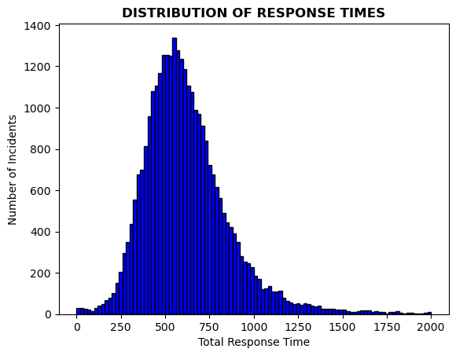

```python
# SHOW CONFIDENCE INTERVALS
data = df_response['TotalResponseTime']

mean = np.mean(data)
std = np.std(data, ddof=1)

confidence_level = 0.95
z_score = stats.norm.ppf((1 + confidence_level) / 2)

margin_of_error = z_score * (std / np.sqrt(len(data)))

confidence_interval = [round(mean - margin_of_error, 2),
                       round(mean + margin_of_error, 2)]

print('CONFIDENCE INTERVALS:')
print('With 95% Confidence, the true '
      'population mean will fall within this range:',
      confidence_interval, '\n')
print('STANDARD DEVIATION:')
print('The standard deviation in seconds is:',
      round(std, 2), '\n')

# SHOW IQR
Q1 = data.quantile(0.25)
Q3 = data.quantile(0.75)
IQR = Q3 - Q1
print('INTER QUARTILE RANGE CALCULATION:')
print('The IQR is at:', (Q1, Q3),
     '\n')


# PLOT DISTRIBUTION OF RESPONSE TIME
plt.hist(df_response['TotalResponseTime'],
         bins=100, range=(0,2000), color='blue',
         edgecolor='black')
plt.xlabel('Total Response Time')
plt.ylabel('Number of Incidents')
plt.title('DISTRIBUTION OF RESPONSE TIMES',
          fontweight='bold')
plt.show()
```

### A.3 Time Series of Average Response Time and Number of Incidents

The time series analysis of response time data reveals a consistent pattern of recurring spikes, especially during the summer months, spanning from June to August. This pattern persists across multiple years, from 2020 through 2023. This observation indicates the presence of seasonality in fire brigade responses, with longer response times during certain periods of the year.

Furthermore, it's noteworthy that response times show a general upward trend throughout the months. This trend is cause for concern, as it suggests that the fire brigade is taking progressively more time to address fire-related incidents. Timely responses are of paramount importance in such cases, making this trend especially alarming.

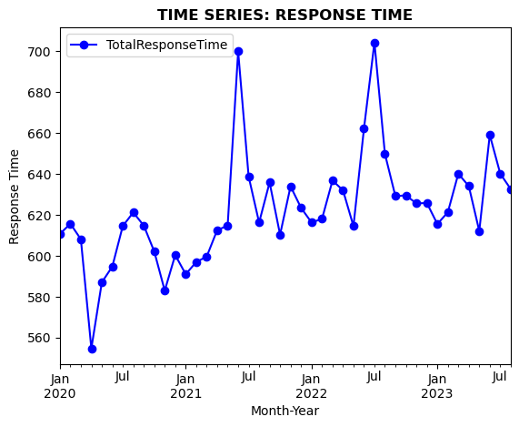

```python
# ADD FLOOR DATE COLUMN
df_response['FloorDate'] = (pd.to_datetime(df_response['DateOfCall'])
                            .dt
                            .to_period('M'))

# PLOT RESPONSE TIME PER PERIOD
response_date = (df_response.groupby('FloorDate')['TotalResponseTime']
                 .agg('mean').reset_index())

response_date.set_index('FloorDate', inplace=True)
response_date.plot(kind='line', y='TotalResponseTime',
                   color='blue', marker='o')

plt.xlabel('Month-Year')
plt.ylabel('Response Time')
plt.title('TIME SERIES: RESPONSE TIME', fontweight='bold')

plt.show()
```

After looking at the trend in response times, it is natural to look at the number of incidents as it is possible that it is one of the factors to response time spikes in the summer. A visual comparison of both response time and incident count plots reveals strikingly similar patterns, notably characterized by spikes occurring during the summer season. It is probable that the number of incidents in these periods play a role in the response time.

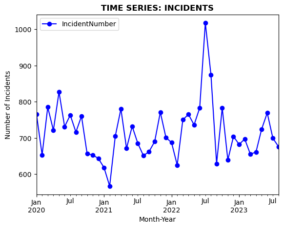

```python
# ADD FLOOR DATE COLUMN
df_response['FloorDate'] = (pd.to_datetime(df_response['DateOfCall'])
                            .dt
                            .to_period('M'))

# PLOT RESPONSE TIME PER PERIOD
response_date = (df_response.groupby('FloorDate')['IncidentNumber']
                 .agg('count').reset_index())

response_date.set_index('FloorDate', inplace=True)
response_date.plot(kind='line', y='IncidentNumber',
                   color='blue', marker='o')

plt.xlabel('Month-Year')
plt.ylabel('Number of Incidents')
plt.title('TIME SERIES: INCIDENTS', fontweight='bold')

plt.show()
```

### A.4 Average Total Response Time per Fire Station

Fire stations exhibit an average response time of 628.92 seconds, with a standard deviation of 64.15 seconds. The data displays notable dispersion from the mean, with some fire stations achieving notably shorter response times, typically falling within the range of 500 to 550 seconds, while others experience comparatively longer response times, ranging from 720 to 790 seconds. This variance can likely be attributed to varying conditions and circumstances that each fire station operates under.

```python
# GET AVERAGE RESPONSE TIME PER FIRESTATION
column = 'TotalResponseTime'
response_per_fs = (df_response
                   .groupby('DeployedFromStation_Name')[column]
                   .agg('mean')
                   .sort_values())
response_per_fs = response_per_fs.to_frame().reset_index()
response_per_fs.columns = ['Station Name', 'Total Response Time']
response_per_fs.set_index(keys='Station Name', inplace=True)

# SHOW MEAN AND STANDARD DEVIATION
data = response_per_fs['Total Response Time']

mean = np.mean(data)
std = np.std(data, ddof=1)

print('MEAN:')
print('The mean in seconds is:',
      round(mean, 2), '\n')
print('STANDARD DEVIATION:')
print('The standard deviation in seconds is:',
      round(std, 2), '\n')
display(response_per_fs)
```

```
MEAN:
The mean in seconds is: 628.92

STANDARD DEVIATION:
The standard deviation in seconds is: 64.15
```

| Station Name | Total Response Time |
| --- | --- |
| Whitechapel | 497.425000 |
| Brixton | 513.644540 |
| Shoreditch | 521.530997 |
| Peckham | 523.888060 |
| Old Kent Road | 524.046784 |
| ... | ... |
| Wennington | 738.156250 |
| Mill Hill | 753.729730 |
| Biggin Hill | 761.739130 |
| Ruislip | 779.277778 |
| Heathrow | 788.658228 |

102 rows × 1 columns

Here are the top-performing fire stations, characterized by the shortest response times, typically ranging between 500 and 550 seconds, as previously mentioned.

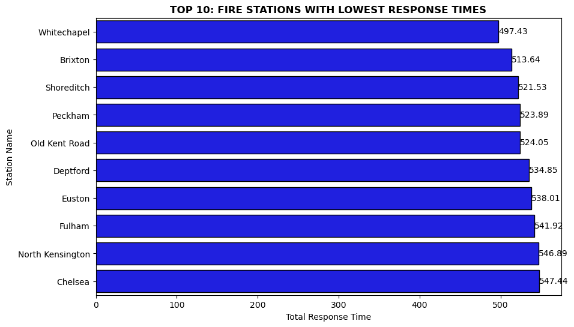

```python
# TOP 10: FIRE STATIONS WITH LOWEST RESPONSE TIMES
top_rsp = response_per_fs[:10]

warnings.filterwarnings("ignore", category=FutureWarning)

plt.figure(figsize=(10, 6))
ax = sns.barplot(x='Total Response Time', y=top_rsp.index,
                 data=top_rsp, orient='h', color='blue',
                 edgecolor='black')

for i, value in enumerate(top_rsp['Total Response Time']):
    ax.text(value, i, f'{value:.2f}', color='black',
            va='center', fontsize=10)

plt.xlabel('Total Response Time')
plt.ylabel('Station Name')
plt.title('TOP 10: FIRE STATIONS WITH LOWEST RESPONSE TIMES',
          fontweight='bold')
plt.show()
```

Here are the bottom-performing fire stations, distinguished by their lengthier response times, generally falling within the range of 720 to 790 seconds, as previously noted.

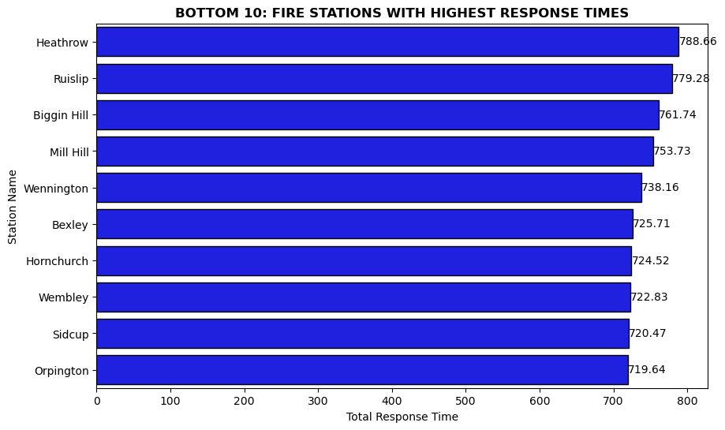

```python
# BOTTOM 10: FIRE STATIONS WITH HIGHEST RESPONSE TIMES
bot_rsp = response_per_fs[::-1][:10]

warnings.filterwarnings("ignore", category=FutureWarning)

plt.figure(figsize=(10, 6))
ax = sns.barplot(x='Total Response Time', y=bot_rsp.index,
                 data=bot_rsp, orient='h', edgecolor='black',
                 color='blue')

for i, value in enumerate(bot_rsp['Total Response Time']):
    ax.text(value, i, f'{value:.2f}', color='black',
            va='center', fontsize=10)

plt.xlabel('Total Response Time')
plt.ylabel('Station Name')
plt.title('BOTTOM 10: FIRE STATIONS WITH HIGHEST RESPONSE TIMES',
          fontweight='bold')
plt.show()
```

## B. Total Response Time Breakdown

The research team undertook an analysis of each component of the response time to identify the most significant contributor. This involved calculating the average turnout time, travel time, and attendance time for each incident and summing these values. To provide a clear representation of these contributions, a pie chart was employed to visualize the percentage share of each component.

### B.1 Pull Total Response Time Data

```python
with sqlite3.connect('lfb_db.db') as conn:
    df_rsptime = pd.read_sql_query("""
    SELECT
         IncidentNumber, DeployedFromStation_Name,
         TurnoutTimeSeconds, TravelTimeSeconds,
         AttendanceTimeSeconds, TotalResponseTime
    FROM
        clean_lfb_table""", conn)
print('PREVIEW DATA:')
display(df_rsptime.head())
```

```
PREVIEW DATA:
```

|  | IncidentNumber | DeployedFromStation_Name | TurnoutTimeSeconds | TravelTimeSeconds | AttendanceTimeSeconds | TotalResponseTime |
| --- | --- | --- | --- | --- | --- | --- |
| 0 | 000003-01012020 | Hillingdon | 78.0 | 246.0 | 324 | 648.0 |
| 1 | 000017-01012020 | Leyton | 88.0 | 193.0 | 281 | 562.0 |
| 2 | 000023-01012020 | North Kensington | 74.0 | 215.0 | 289 | 578.0 |
| 3 | 000040-01012020 | Beckenham | 89.0 | 221.0 | 310 | 620.0 |
| 4 | 000049-01012020 | East Ham | 139.0 | 165.0 | 304 | 608.0 |

### B.2 Components of Total Response Time

The pie chart below reveals that attendance time and travel time collectively account for the highest percentage contribution to the overall response time, comprising approximately 88.5% of the total. This indicates that a significant portion of the response time is devoted to activities such as traveling from the station to the incident location, setting up a command center at the scene, and deploying firefighters.

While turnout time has the smallest contribution, it is imperative to thoroughly examine all components, given the critical nature of fire-related incidents. Any insights gained, particularly regarding the turnout time component, can provide valuable assistance in potentially optimizing response times, which can be a matter of life or death in emergency situations.

```
COMPONENTS OF RESPONSE TIME:
```

|  | Component | AverageTime |
| --- | --- | --- |
| 0 | Turnout Time | 72.0 |
| 1 | Travel Time | 240.0 |
| 2 | Attendance Time | 312.0 |

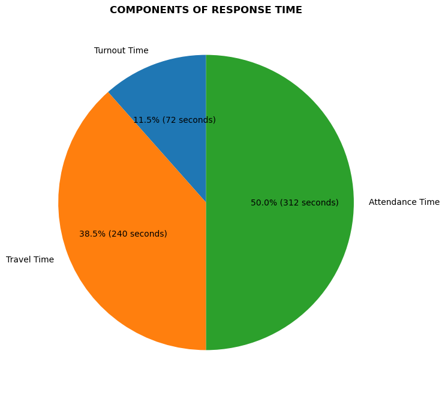

```python
# CALCULATE AVERAGE TURNOUT, TRAVEL, AND ATTENDANCE TIMES
response_time = df_rsptime[['TurnoutTimeSeconds',
                            'TravelTimeSeconds',
                            'AttendanceTimeSeconds']]
response_time = (response_time
                 .agg('mean')
                 .round(0)
                 .to_frame(name='AverageTime'))
response_time = (response_time
                 .reset_index()
                 .rename(columns={'index': 'Component'}))
response_time['Component'] = ['Turnout Time', 'Travel Time',
                              'Attendance Time']
print('COMPONENTS OF RESPONSE TIME:')
display(response_time)

# PLOT AVERAGE TURNOUT, TRAVEL, AND ATTENDANCE TIMES
plt.figure(figsize=(8, 8))
plt.pie(response_time['AverageTime'],
        labels=response_time['Component'], startangle=90,
        autopct=(lambda p: '{:.1f}% ({:.0f} seconds)'
                 .format(p, p * sum(response_time['AverageTime']) / 100)))
plt.title('COMPONENTS OF RESPONSE TIME', fontweight='bold',
         loc='center')
```

## C. Turnout Time Breakdown

Turnout Time is the time from the start of when the incident is first flagged by the caller, to when the responding fire station sends out its first asset out of the station.

The research team suspected that the timing of the dispatcher's call to the fire station might influence the turnout time duration. To investigate this, they intend to analyze both a line graph depicting turnout time versus the hour of the call and the distribution of incidents across different hours of the day. By comparing these two aspects, the team aims to gain insights into the potential relationship between the timing of the call and turnout time.

### C.1 Pull Turnout Time Data

```python
with sqlite3.connect('lfb_db.db') as conn:
    df_turnout = pd.read_sql_query("""
    SELECT
         HourOfCall, TurnoutTimeSeconds AS TurnoutTime
    FROM
        clean_lfb_table""", conn)
print('PREVIEW DATA:')
display(df_turnout.head())
```

```
PREVIEW DATA:
```

|  | HourOfCall | TurnoutTime |
| --- | --- | --- |
| 0 | 0 | 78.0 |
| 1 | 0 | 88.0 |
| 2 | 0 | 74.0 |
| 3 | 0 | 89.0 |
| 4 | 0 | 139.0 |

### C.2 Distribution of Incidents per Hour of Day

The analysis reveals a noticeable decrease in incidents during the early morning hours, particularly from 5:00 AM to 7:00 AM, and a peak in incidents around 6:00 PM to 7:00 PM. In general, the number of incidents in the morning is significantly lower compared to the higher frequency of incidents during the afternoon and evening. While the distribution of incidents per hour of the day offers some insights, a comprehensive conclusion requires a comparative analysis with another graph, which is the turnout time vs. hour of call graph.

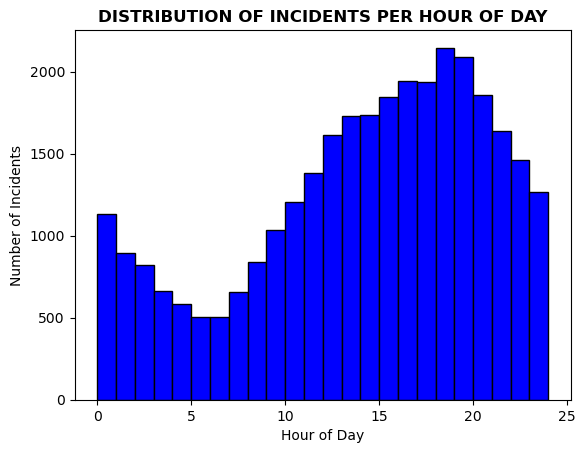

```python
# PLOT DISTRIBUTION OF INCEDENTS PER HOUR OF DAY
plt.hist(df_turnout['HourOfCall'], bins=24,
         range=(0,24), edgecolor='black',
         color='blue')
plt.xlabel('Hour of Day')
plt.ylabel('Number of Incidents')
plt.title('DISTRIBUTION OF INCIDENTS PER HOUR OF DAY',
          fontweight='bold')
plt.show()
```

### C.3 Average Turnout Time vs. Hour of Call

The turnout time exhibits its longest durations in the morning, specifically between 12:00 AM and 7:00 AM. It experiences a decline around 8:00 AM and maintains consistently shorter durations until approximately 10:00 PM to 11:00 PM. What's particularly noteworthy is the inverse relationship observed between the turnout time in response to the hour of the call and the number of incidents at different hours of the day. When the turnout time is at its peak, incident frequency is lower, and conversely, when turnout time is shorter, the number of incidents tends to be higher.

The key insight here is that the hour of the emergency call does appear to influence the turnout time, with variations observed at different times of the day. However, it is important to note that while there is a correlation, it's not definitive that the number of incidents is the sole reason for the high turnout time during certain periods. Other factors may be at play, but unfortunately, the London Fire Brigade mobilization and incident dataset lacks many features that could provide a more comprehensive explanation for turnout time variations.

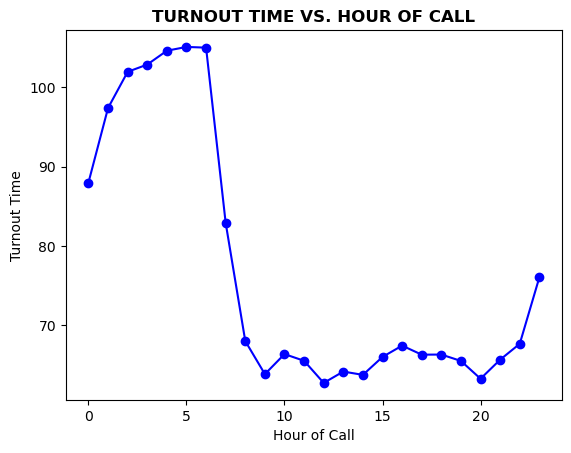

```
AVERAGE TURNOUT TIME PER HOUR OF DAY
```

|  | HourOfCall | TurnoutTime |
| --- | --- | --- |
| 0 | 0 | 87.994700 |
| 1 | 1 | 97.398883 |
| 2 | 2 | 101.959707 |
| 3 | 3 | 102.873303 |
| 4 | 4 | 104.617900 |
| 5 | 5 | 105.097030 |
| 6 | 6 | 105.005976 |
| 7 | 7 | 82.905199 |
| 8 | 8 | 68.014252 |
| 9 | 9 | 63.853423 |
| 10 | 10 | 66.376763 |
| 11 | 11 | 65.531884 |
| 12 | 12 | 62.744114 |
| 13 | 13 | 64.176028 |
| 14 | 14 | 63.758362 |
| 15 | 15 | 66.020630 |
| 16 | 16 | 67.444616 |
| 17 | 17 | 66.305943 |
| 18 | 18 | 66.320746 |
| 19 | 19 | 65.514586 |
| 20 | 20 | 63.272091 |
| 21 | 21 | 65.673794 |
| 22 | 22 | 67.675103 |
| 23 | 23 | 76.045922 |

```python
turnout_hour = (df_turnout.groupby('HourOfCall')
                .agg('mean')
                .reset_index())

plt.plot(turnout_hour['HourOfCall'],
         turnout_hour['TurnoutTime'],
         color='blue', marker='o')
plt.xlabel('Hour of Call')
plt.ylabel('Turnout Time')
plt.title('TURNOUT TIME VS. HOUR OF CALL', fontweight='bold')

plt.show()
print('\nAVERAGE TURNOUT TIME PER HOUR OF DAY')
display(turnout_hour)
```

## D. Travel Time Breakdown

Travel time is the time beginning from the departure of the responding fire station and the arrival to the incident location. The travel time is influenced by the distance, delays, and travel speed.

### D.1 PULL TRAVEL TIME DATA

```python
with sqlite3.connect('lfb_db.db') as conn:
    df_travel = pd.read_sql_query("""
    SELECT
         IncidentNumber, DeployedFromStation_Name,
         "DistanceToIncident (KM)", TravelTimeSeconds,
         "TravelSpeed (KM/HR)", IsDelayed
    FROM
        clean_lfb_table""",
    con=conn, parse_dates='DateOfCall')
print('PREVIEW DATA:')
display(df_travel.head())
```

```
PREVIEW DATA:
```

|  | IncidentNumber | DeployedFromStation_Name | DistanceToIncident (KM) | TravelTimeSeconds | TravelSpeed (KM/HR) | IsDelayed |
| --- | --- | --- | --- | --- | --- | --- |
| 0 | 000003-01012020 | Hillingdon | 1.34 | 246.0 | 19.609756 | 0 |
| 1 | 000017-01012020 | Leyton | 0.20 | 193.0 | 3.730570 | 0 |
| 2 | 000023-01012020 | North Kensington | 1.36 | 215.0 | 22.772093 | 0 |
| 3 | 000040-01012020 | Beckenham | 3.24 | 221.0 | 52.778281 | 0 |
| 4 | 000049-01012020 | East Ham | 1.07 | 165.0 | 23.345455 | 0 |

### D.2 DISTRIBUTION OF INCIDENTS BY TRAVEL SPEED (KM/HR)

The average travel time is 29 km/h, however, this follows a right skewed distribution.

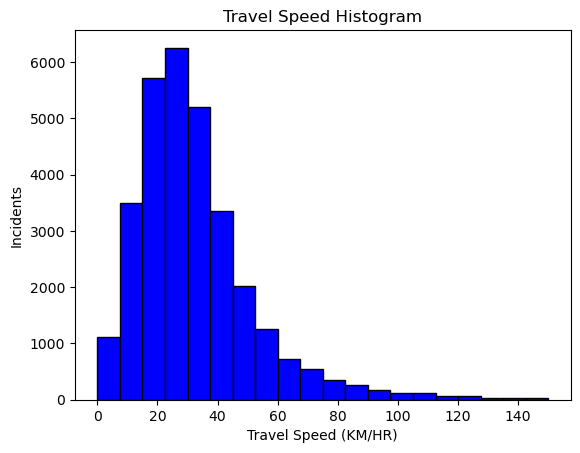

```python
# Extract the data from the DataFrame column
data = df_travel['TravelSpeed (KM/HR)']

# Create the histogram
plt.hist(data, bins=20, range=(0,150),
         color='blue', edgecolor='black')

# Customize the plot
plt.title('Travel Speed Histogram')
plt.xlabel('Travel Speed (KM/HR)')
plt.ylabel('Incidents')

# Display the histogram
plt.show()
```

### D.3 Mean Travel Time by IsDelayed (Plumstead Station)

Plumstead station is the fire station that responds to the largest number of incidences in London. To observe the impact of delays on travel speed, Plumstead data was used. This is because some fire stations that have average high travel speeds due to their location would skew the data.

It was found that delays reduced the average travel speed by an average of 30 KM/HR, or around 55%.

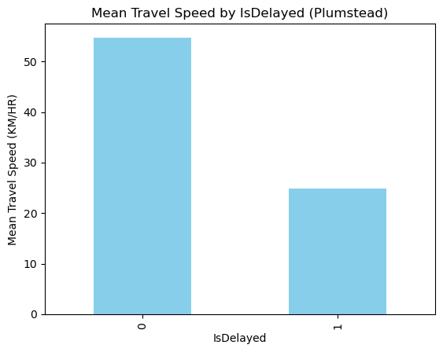

```python
# Assuming you have a DataFrame named df_lfb

# Group the data by 'IsDelayed' and calculate the mean of 'TravelSpeed (KM/HR)'
data = df_travel.loc[df_travel.DeployedFromStation_Name == 'Plumstead',
                     ['IsDelayed', 'TravelSpeed (KM/HR)']]

grouped_data = data.groupby('IsDelayed')['TravelSpeed (KM/HR)'].mean()

# Create the bar chart
grouped_data.plot(kind='bar', color='skyblue')

# Customize the plot
plt.title('Mean Travel Speed by IsDelayed (Plumstead)')
plt.xlabel('IsDelayed')
plt.ylabel('Mean Travel Speed (KM/HR)')

# Display the bar chart
plt.show()
```

### D.4 Average Speed vs. Distance to Incident for Firestations

Fire stations were plotted against their average travel speeds and average distance traveled to an incident. It was found that there was a linear relationship between the two variables. This is beneficial relationship as it indicates that fire stations that are able to travel faster are allocated to further incidences, while stations which experience slower travel speeds are allocated towards nearby incidences. The net effect is more equitable total travel times.

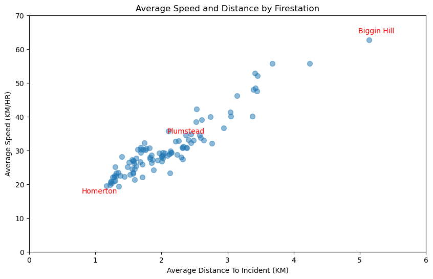

```python
grouped_df = df_travel.groupby('DeployedFromStation_Name').agg({
    'TravelTimeSeconds': 'sum',
    'DistanceToIncident (KM)': ['sum', 'mean']
})

# Reset column names for the resulting DataFrame
grouped_df.columns = ['Sum_TravelTime', 'Sum_Distance', 'Avg_Distance (KM)']

# Reset the index to make 'DeployedFromStation_Name' a regular column
grouped_df.reset_index(inplace=True)

# Get average speed
grouped_df['Avg_Speed'] = grouped_df['Sum_Distance'] / \
    grouped_df['Sum_TravelTime'] * 3600

# Create Scatter Plot
x = grouped_df['Avg_Distance (KM)']
y = grouped_df['Avg_Speed']

# Create the scatterplot
plt.figure(figsize=(10, 6))
plt.scatter(x, y, marker='o', s=50, alpha=0.5)

# Set labels and title
plt.xlabel('Average Distance To Incident (KM)')
plt.ylabel('Average Speed (KM/HR)')
plt.title('Average Speed and Distance by Firestation')

# Set axis min and max
max_x = np.ceil(max(x))
plt.xlim(0, max_x)
max_y = np.ceil(max(y) / 10) * 10
plt.ylim(0, max_y)

# Comment here
left_most = grouped_df[grouped_df['Avg_Distance (KM)'] == x.min()]
right_most = grouped_df[grouped_df['Avg_Distance (KM)'] == x.max()]
plumstead = grouped_df[grouped_df['DeployedFromStation_Name'] == 'Plumstead']


plt.annotate(left_most['DeployedFromStation_Name'].values[0],
             (left_most['Avg_Distance (KM)'].iloc[0],
              left_most['Avg_Speed'].iloc[0]),
             textcoords="offset points", xytext=(-10, -10),
             ha='center', fontsize=10, color='red')

plt.annotate(right_most['DeployedFromStation_Name'].values[0],
             (right_most['Avg_Distance (KM)'].iloc[0],
              right_most['Avg_Speed'].iloc[0]),
             textcoords="offset points", xytext=(10, 10),
             ha='center', fontsize=10, color='red')

plt.annotate('Plumstead',
             (plumstead['Avg_Distance (KM)'].iloc[0],
              plumstead['Avg_Speed'].iloc[0]),
             textcoords="offset points", xytext=(10, 10),
             ha='center', fontsize=10, color='red')

# Display the plot
plt.show()

# Linear upward line means that firestations that are expected to face delays
# and traffic are located closer together to reduce travel time
```

## E. Attendance Time Breakdown

Attendance time is the time from the arrival of the first pump to the incident location to the end of its set-up and preparation to begin operations.

### E.1 PULL ATTENDANCE TIME DATA

```python
with sqlite3.connect('lfb_db.db') as conn:
    df_attendance = pd.read_sql_query("""
    SELECT
         IncidentNumber, DeployedFromStation_Name,
         AttendanceTimeSeconds, AddressQualifier
    FROM
        clean_lfb_table""", con=conn, parse_dates='DateOfCall')
print('PREVIEW DATA:')
display(df_attendance.head())
```

```
PREVIEW DATA:
```

|  | IncidentNumber | DeployedFromStation_Name | AttendanceTimeSeconds | AddressQualifier |
| --- | --- | --- | --- | --- |
| 0 | 000003-01012020 | Hillingdon | 324 | On land associated with building |
| 1 | 000017-01012020 | Leyton | 281 | Correct incident location |
| 2 | 000023-01012020 | North Kensington | 289 | Correct incident location |
| 3 | 000040-01012020 | Beckenham | 310 | Correct incident location |
| 4 | 000049-01012020 | East Ham | 304 | On land associated with building |

### E.2 Attendance Time Distribution

It was found that the mean attendance time for the LFB was around 311 seconds, however, this distribution followed a right-skewed distribution.

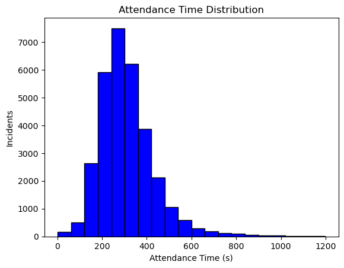

```python
# Extract the data from the DataFrame column
data = df_attendance['AttendanceTimeSeconds']

# Create the histogram
plt.hist(data, bins=20, color='blue', edgecolor='black')

# Customize the plot
plt.title('Attendance Time Distribution')
plt.xlabel('Attendance Time (s)')
plt.ylabel('Incidents')

# Display the histogram
plt.show()
```

### E.3 MEAN ATTENDANCE TIME BY ADDRESS QUALIFIER

Investigating the attendance time further, it was found that the Address Qualifier feature had a significant impact on the attendance time.

Most significantly, incidences that occurred on a motorway or elevated road required the most time to attend to at 461 seconds on average.

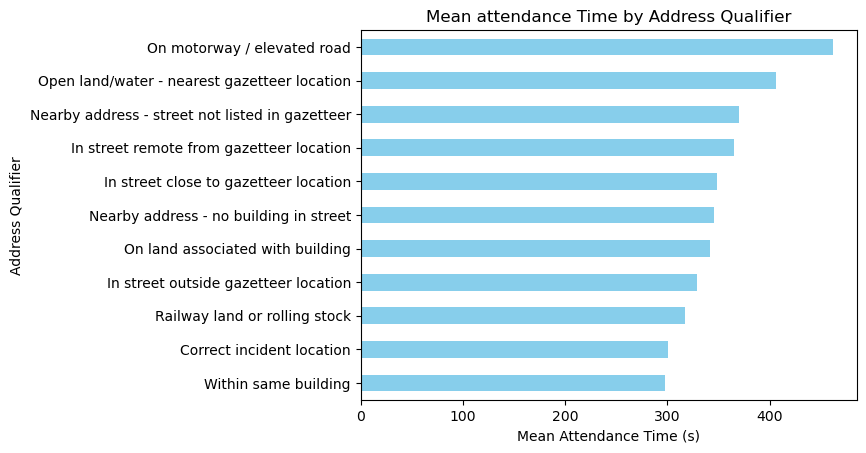

```python
grouped_data = df_attendance.groupby('AddressQualifier')[
    'AttendanceTimeSeconds'].mean().sort_values()

# Create the bar chart
grouped_data.plot(kind='barh', color='skyblue')

# Customize the plot
plt.title('Mean attendance Time by Address Qualifier')
plt.xlabel('Mean Attendance Time (s)')
plt.ylabel('Address Qualifier')

# Display the bar chart
plt.show()
```

# VI. CONCLUSION

The conclusions below discuss each of the insights and findings about the overall response time and the components that are under it, which are turnout time, travel time, and attendance time.

When examining the response time holistically, it becomes evident that there is a notable influence of seasonality on response times. Specifically, a substantial increase in response times for the London Fire Brigade occurs during the summer months (June to August). Further investigation into the number of incidents as a potential contributing factor reveals a parallel trend. Consequently, it can be inferred that the seasonal spikes in response times are primarily attributed to the increased volume of incidents during these periods. Given this information, the London Fire Brigade can look at solutions on how they can account for demand in incidents during peak months.

Upon dissecting the components that make up response time, it becomes clear that travel time and attendance time are the predominant factors influencing the overall duration. Based on this understanding, it is advisable for the brigade to place a higher emphasis on enhancing these two components before embarking on efforts to reduce turnout time.

The hour of the call appears to have a discernible impact on the average turnout time, with noticeable fluctuations between high and low response times at different times of the day. Specifically, the morning hours exhibit longer response times, while the afternoon and evening hours tend to see quicker responses. Notably, our analysis indicates that the number of incidents within a specific daily timeframe is not the exclusive determinant of these fluctuations. As a result, it is imperative to delve into other contributing factors to uncover a comprehensive explanation.

Delays and the location of the fire station have a significant impact on the average travel time of that station to the incident. However, this seems to be already factored as slower stations are not often utilized to respond to further incidences.

Attendance time for certain Address Qualifiers is much longer than the average, especially for incidences on the motorway. Improved methods for responding to these types of incidences would reduce the right skew.

# VII. RECOMMENDATION

**Timing Limitations**

- The allotted time to conduct the report is more or less two weeks. Therefore, there is little to no time to conduct deep analysis on the impact of each factor on response time and its components. This is why the team settled on visualization techniques and statistical tools.

**Dataset and Parameter Limitations:**

**Limitations on Coordinate Conversions:**

- Distance was an important aspect of this study, however, much of the dataset had missing values for coordinate data. Additionally, of the coordinate data that was available, the numbers were rounded. The effect of this is inaccuracy in determining the distance which therefore affects our speed calculation which was a key KPI that was analyzed.
- Addition, the method for converting Easting and Northing coordinates was calculated using linear approximation as it was too computationally expensive to use pyproj functions for each set of coordinates. This slightly contributes to the inaccuracies in calculating distance as linear conversion assumes a flat plane. However, the Earth is not flat and has a curvature which means that the distance between 1 degree of longitude or latitude is different depending on the starting point on Earth. This was ignored due to the fact that this study was analyzing London data point only rather than larger distances where the curvature would be more pronounced.

**Limitations on Distance Calculation:**

- Distance was calculated assuming a straight line. This is an approximation as vehicles must travel along roads and avenues with many irregular turns along the way. Total distance traveled is therefore underestimated.

**Recommendations for Further Studies:**

- This study broadly investigated some of the features which impact Turnout Time, Travel Time, and Attendance Time. Further investigations could surface richer insights by investigating the cross-feature effects on these KPIs. This would involve analyzing two or more parameters simultaneously and understanding their impact on each other as well as on the Response Time. This would require further data cleaning, feature engineering, and regrouping of certain fields to render them usable. A potential output of further study would be identifying how assets could be re-organized or shifted to better optimize and prepare for incidences.
- For future research endeavors, it is recommended to collect and integrate supplementary features into the London Fire Brigade's incidents and mobilization datasets. While the current study incorporated fire station latitude and longitude into the feature engineering process, there exist numerous other variables that can be incorporated to enhance the analysis.

# References (Links)

[1] Pyproj Contributors. (2023). pyproj (Version 3.6.1) [Software]. https://pypi.org/project/pyproj/  
[2] Doe, J. (2023). haversine (Version 2.8.0) [Software]. https://pypi.org/project/haversine/  
[3] Graphviz authors. (2023). Graphviz Python library (Version 0.20.1) [Software]. Available from https://www.graphviz.org/  
[4] Pillow authors. (2023). Pillow (PIL Fork) Python library (Version 10.1.0) [Software]. Available from https://python-pillow.org/  
[5] Pérez, F., & Granger, B. E. (2023). IPython: A system for interactive scientific computing (Version 8.17.1) [Software]. Available from https://ipython.org/  
[6] Elgueta, B. J. F. M. O. &. A. (2023, August 20). Fire brigade response times across England highest in 10 years, data shows. BBC News. https://www.bbc.com/news/uk-england-london-66544094  
[7] London Fire Brigade Incident Records – London Datastore. (2023, September 30). Retrieved October 26, 2023, from https://data.london.gov.uk/dataset/london-fire-brigade-incident-records  
[8] London Fire Brigade Mobilisation Records – London Datastore. (2023, September 30). Retrieved October 26, 2023, from https://data.london.gov.uk/dataset/london-fire-brigade-mobilisation-records  
[9] Horton, H. (December 30, 2022). Summer wildfires increased fourfold in England in 2022. https://www.theguardian.com/world/2022/dec/30/summer-wildfires-increased-fourfold-in-england-in-2022  
[10] Note that ChatGPT was used for editing grammar and rewording statements.